# Team_7

# Description

Team 7 consists of 3 members: HEO ShinIl (Team Leader), KANG MinKyu, JUNG JuWon.

This document describes processes of data analysis of movie. The data came from Kofic, which is Korean Film Council.

The data is available on the urls below:

- all movies listed in Kofic (https://www.kobis.or.kr/kobis/business/mast/mvie/searchMovieList.do)
- Data related with sales rev etc. (https://www.kobis.or.kr/kobis/business/stat/offc/searchOfficHitTotList.do?searchMode=year)

# Purpose

- Identify impact of Covid-19 on Film Industry.
- Identify significant factors that have effects on Box office.

# Data Cleaning

Raw data has two files: general information of movies and sales information of movies.

Before using R command, we merged them by using vlookup function in MS office Excel.

```r
#install.packages('lubridate')
library(lubridate)
library(dplyr)
```

```r
library(ggplot2)
```

At first, load data To deal with Korean characters, this r codes are encoded as ‘utf-8’

If errors on loading data, reopen this document with ‘utf-8’

```r
df <- read.csv('Movie Data.csv')
```

Check types of variables in the data

```r
summary(df)
```

```
##     영화명          영화명.영문.          제작연도      제작국가
##  Length:82050       Length:82050       Min.   :1874   Length:82050
##  Class :character   Class :character   1st Qu.:1999   Class :character
##  Mode  :character   Mode  :character   Median :2011   Mode  :character
##                                        Mean   :2005
##                                        3rd Qu.:2016
##                                        Max.   :2022
##                                        NA's   :3698
##      유형               장르             제작상태             감독
##  Length:82050       Length:82050       Length:82050       Length:82050
##  Class :character   Class :character   Class :character   Class :character
##  Mode  :character   Mode  :character   Mode  :character   Mode  :character
##
##
##
##
##     제작사             감독.1            제작사.1            수입사
##  Length:82050       Length:82050       Length:82050       Length:82050
##  Class :character   Class :character   Class :character   Class :character
##  Mode  :character   Mode  :character   Mode  :character   Mode  :character
##
##
##
##
##     배급사             개봉일            영화유형           영화형태
##  Length:82050       Length:82050       Length:82050       Length:82050
##  Class :character   Class :character   Class :character   Class :character
##  Mode  :character   Mode  :character   Mode  :character   Mode  :character
##
##
##
##
##      국적           전국.스크린수      전국.매출액        전국.관객수
##  Length:82050       Length:82050       Length:82050       Length:82050
##  Class :character   Class :character   Class :character   Class :character
##  Mode  :character   Mode  :character   Mode  :character   Mode  :character
##
##
##
##
##  서울.매출액        서울.관객수           장르.1              등급
##  Length:82050       Length:82050       Length:82050       Length:82050
##  Class :character   Class :character   Class :character   Class :character
##  Mode  :character   Mode  :character   Mode  :character   Mode  :character
##
##
##
##
##    영화구분
##  Length:82050
##  Class :character
##  Mode  :character
##
##
##
##
```

Not all columns are used in this analysis.

This Data have some duplicate columns.

It is because of that two files (the general information and the sales information) have some same columns such as 감독(directors).

For columns we use for this analysis, change name of columns into English for easier processing.

```r
#colnames(df)

colnames(df)[1] <- 'Name'
colnames(df)[14] <- 'Release_Date'
colnames(df)[17] <- 'Nationality'
colnames(df)[18] <- 'Total_screens'
colnames(df)[19] <- 'Box_office'
colnames(df)[20] <- 'Audience'
colnames(df)[23] <- 'Genre'
colnames(df)[24] <- 'Rate'
colnames(df)[25] <- 'Artistic'

colnames(df)
```

```
##  [1] "Name"          "영화명.영문."  "제작연도"      "제작국가"
##  [5] "유형"          "장르"          "제작상태"      "감독"
##  [9] "제작사"        "감독.1"        "제작사.1"      "수입사"
## [13] "배급사"        "Release_Date"  "영화유형"      "영화형태"
## [17] "Nationality"   "Total_screens" "Box_office"    "Audience"
## [21] "서울.매출액"   "서울.관객수"   "Genre"         "Rate"
## [25] "Artistic"
```

Drop columns other than Name, Release Date, Nationality, Total Screens, Box Office, Audience, Genre, Rate, Artistic

```r
df_edit_col <- df %>% select(Name, Release_Date, Nationality,
                      Total_screens, Box_office, Audience,
                      Genre, Rate, Artistic)

colnames(df_edit_col)
```

```
## [1] "Name"          "Release_Date"  "Nationality"   "Total_screens"
## [5] "Box_office"    "Audience"      "Genre"         "Rate"
## [9] "Artistic"
```

Convert Release Date from numeric to visible format by using ymd functions in lubridate.

```r
df_edit_col$Release_Date <- ymd(df_edit_col$Release_Date)
class(df_edit_col$Release_Date)
```

```
## [1] "Date"
```

Audience, Box office, Total screen are currently character value.

Convert Audience & Box Office & Total Screen into numerical value.

```r
df_edit_col$Audience <- as.numeric(df_edit_col$Audience)
df_edit_col$Box_office <- as.numeric(df_edit_col$Box_office)
df_edit_col$Total_screens <- as.numeric(df_edit_col$Total_screens)
```

For columns of Rate, Genre, Nationality and Artistic, they are written in Korean. For easier processing, translate the values into English.

- All
- Over 12
- Over 15
- Over 16
- Over 18
- Restricted
- Not Decided

```r
df_edit_col[df_edit_col["Rate"] == '12세이상관람가',"Rate"] = "Over_12"
df_edit_col[df_edit_col["Rate"] == '국민학생관람불가',"Rate"] = "Over_12"
df_edit_col[df_edit_col["Rate"] == '전체관람가',"Rate"] = "All"
df_edit_col[df_edit_col["Rate"] == '15세관람가',"Rate"] = "Over_15"
df_edit_col[df_edit_col["Rate"] == '15세이상관람가',"Rate"] = "Over_15"
df_edit_col[df_edit_col["Rate"] == '중학생이상관람가',"Rate"] = "Over_15"
df_edit_col[df_edit_col["Rate"] == '12세이상관람가,12세관람가',"Rate"] = "Over_12"
df_edit_col[df_edit_col["Rate"] == '18세 미만인 자는 관람할 수 없는 등급',"Rate"] = "Over_18"
df_edit_col[df_edit_col["Rate"] == '18세관람가,15세이상관람가',"Rate"] = "Over_18"
df_edit_col[df_edit_col["Rate"] == '연소자관람불가',"Rate"] = "Over_18"
df_edit_col[df_edit_col["Rate"] == '청소년관람불가',"Rate"] = "Over_18"
df_edit_col[df_edit_col["Rate"] == '12세관람가',"Rate"] = "Over_12"
df_edit_col[df_edit_col["Rate"] == '15세 미만인 자는 관람할 수 없는 등급',"Rate"] = "Over_15"
df_edit_col[df_edit_col["Rate"] == '고등학생이상관람가',"Rate"] = "Over_16"
df_edit_col[df_edit_col["Rate"] == '12세이상관람가,연소자관람가',"Rate"] = "Over_12"
df_edit_col[df_edit_col["Rate"] == '15세관람가,15세이상관람가',"Rate"] = "Over_15"
df_edit_col[df_edit_col["Rate"] == '18세관람가',"Rate"] = "Over_18"
df_edit_col[df_edit_col["Rate"] == '미성년자관람불가',"Rate"] = "Over_18"
df_edit_col[df_edit_col["Rate"] == '15세이상관람가,중학생이상관람가',"Rate"] = "Over_15"
df_edit_col[df_edit_col["Rate"] == '연소자관람가',"Rate"] = "All"
df_edit_col[df_edit_col["Rate"] == '고등학생이상관람가,15세이상관람가',"Rate"] = "Over_15"
df_edit_col[df_edit_col["Rate"] == '연소자관람불가,청소년관람불가',"Rate"] = "Over_18"
df_edit_col[df_edit_col["Rate"] == '연소자관람불가,15세이상관람가',"Rate"] = "Over_15"
df_edit_col[df_edit_col["Rate"] == '18세관람가,청소년관람불가',"Rate"] = "Over_18"
df_edit_col[df_edit_col["Rate"] == '미성년자관람가',"Rate"] = "Over_18"
df_edit_col[df_edit_col["Rate"] == '모든 관람객이 관람할 수 있는 등급,전체관람가',"Rate"] = "All"
df_edit_col[df_edit_col["Rate"] == '12세이상관람가,전체관람가',"Rate"] = "Over_12"
df_edit_col[df_edit_col["Rate"] == '12세이상관람가,고등학생이상관람가',"Rate"] = "Over_16"
df_edit_col[df_edit_col["Rate"] == '12세이상관람가,국민학생관람불가,15세이상관람가',"Rate"] = "Over_12"
df_edit_col[df_edit_col["Rate"] == '연소자관람가,전체관람가',"Rate"] = "All"
df_edit_col[df_edit_col["Rate"] == '청소년관람불가,15세이상관람가',"Rate"] = "Over_15"
df_edit_col[df_edit_col["Rate"] == '모든 관람객이 관람할 수 있는 등급',"Rate"] = "All"
df_edit_col[df_edit_col["Rate"] == '12세이상관람가,15세이상관람가',"Rate"] = "Over_12"
df_edit_col[df_edit_col["Rate"] == '12세 미만인 자는 관람할 수 없는 등급',"Rate"] = "Over_12"
df_edit_col[df_edit_col["Rate"] == '12세이상관람가,15세 미만인 자는 관람할 수 없는 등급',"Rate"] = "Over_15"
df_edit_col[df_edit_col["Rate"] == '12세이상관람가,중학생이상관람가',"Rate"] = "Over_15"
df_edit_col[df_edit_col["Rate"] == '15세이상관람가,미성년자관람불가',"Rate"] = "Over_18"
df_edit_col[df_edit_col["Rate"] == '연소자관람가,15세이상관람가',"Rate"] = "Over_15"
df_edit_col[df_edit_col["Rate"] == '청소년관람불가,12세관람가',"Rate"] = "Over_18"
df_edit_col[df_edit_col["Rate"] == '15세 미만인 자는 관람할 수 없는 등급 ,15세이상관람가',"Rate"] = "Over_15"
df_edit_col[df_edit_col["Rate"] == '15세이상관람가,전체관람가',"Rate"] = "Over_15"
df_edit_col[df_edit_col["Rate"] == '15세이상관람가,18세 미만인 자는 관람할 수 없는 등급',"Rate"] = "Over_18"
df_edit_col[df_edit_col["Rate"] == '국민학생관람불가,청소년관람불가',"Rate"] = "Over_18"
df_edit_col[df_edit_col["Rate"] == '청소년관람불가,고등학생이상관람가',"Rate"] = "Over_18"
df_edit_col[df_edit_col["Rate"] == '고등학생이상관람가,청소년관람불가',"Rate"] = "Over_18"
df_edit_col[df_edit_col["Rate"] == '국민학생관람불가,15세이상관람가',"Rate"] = "Over_15"
df_edit_col[df_edit_col["Rate"] == '15세관람가,12세이상관람가',"Rate"] = "Over_15"
df_edit_col[df_edit_col["Rate"] == '기타',"Rate"] = "Others"
df_edit_col[df_edit_col["Rate"] == '국민학생관람불가,중학생이상관람가',"Rate"] = "Over_15"
df_edit_col[df_edit_col["Rate"] == '미정',"Rate"] = "Not decided"
df_edit_col[df_edit_col["Rate"] == '청소년관람불가,전체관람가',"Rate"] = "Over_18"
df_edit_col[df_edit_col["Rate"] == '전체관람가,중학생이상관람가',"Rate"] = "Over_15"
df_edit_col[df_edit_col["Rate"] == '제한상영가',"Rate"] = "Restricted"
```

```r
table(df_edit_col$Rate)
```

```
##
##        #N/A           0         All Not decided      Others     Over_12
##       56656         539        2856           2           3        3791
##     Over_15     Over_16     Over_18  Restricted
##        5938        1014       11250           1
```

For Genre, translate them into English.

```r
df_edit_col[df_edit_col['Genre']=='가족','Genre'] <- "Family"
df_edit_col[df_edit_col['Genre']=='공연','Genre'] <- "Play"
df_edit_col[df_edit_col['Genre']=='공포(호러)','Genre'] <- "Horror"
df_edit_col[df_edit_col['Genre']=='기타','Genre'] <- "Others"
df_edit_col[df_edit_col['Genre']=='다큐멘터리','Genre'] <- "Documentary"
df_edit_col[df_edit_col['Genre']=='드라마','Genre'] <- "Drama"
df_edit_col[df_edit_col['Genre']=='멜로/로맨스','Genre'] <- "Romans"
df_edit_col[df_edit_col['Genre']=='뮤지컬','Genre'] <- "Musical"
df_edit_col[df_edit_col['Genre']=='미스터리','Genre'] <- "Mystery"
df_edit_col[df_edit_col['Genre']=='범죄','Genre'] <- "Crime"
df_edit_col[df_edit_col['Genre']=='사극','Genre'] <- "Historic"
df_edit_col[df_edit_col['Genre']=='서부극(웨스턴)','Genre'] <- "Western"
df_edit_col[df_edit_col['Genre']=='성인물(에로)','Genre'] <- "Erotic"
df_edit_col[df_edit_col['Genre']=='스릴러','Genre'] <- "Thriller"
df_edit_col[df_edit_col['Genre']=='애니메이션','Genre'] <- "Animation"
df_edit_col[df_edit_col['Genre']=='액션','Genre'] <- "Action"
df_edit_col[df_edit_col['Genre']=='어드벤처','Genre'] <- "Adventure"
df_edit_col[df_edit_col['Genre']=='전쟁','Genre'] <- "War"
df_edit_col[df_edit_col['Genre']=='코미디','Genre'] <- "Comedy"
df_edit_col[df_edit_col['Genre']=='판타지','Genre'] <- "Fantasy"
table(df_edit_col$Genre)
```

```
##
##        #N/A           0      Action   Adventure   Animation      Comedy
##       56656         197        2959         165        1127        1612
##       Crime Documentary       Drama      Erotic      Family     Fantasy
##         630         730        7006        1813         256         200
##    Historic      Horror     Musical     Mystery      Others        Play
##         297        1223          72         342         111         294
##      Romans          SF    Thriller         War     Western
##        4685         606         868         147          54
```

Artistic Column has two values

- Artistic
- Not Artistic

These values are also written in Korean, we translate them into English.

```r
df_edit_col[df_edit_col["Artistic"]=="독립/예술영화","Artistic"] <- "Artistic"
df_edit_col[df_edit_col["Artistic"]=="일반영화","Artistic"] <- "Not_Artistic"
```

```r
table(df_edit_col$Artistic)
```

```
##
##         #N/A     Artistic Not_Artistic
##        56656         5939        19455
```

Skip rows with NAs’

```r
df_skip_na <- na.omit(df_edit_col)
```

After, we identified rows with all 0s in Box Office, Audience, and number of screens.

We concluded that two cases are possible:

1. they are missing values
2. they are listed on Kofic system but not be shown to the public.

So, we skip these rows.

```r
df_skip_na_0s <- df_skip_na %>%
  filter(Total_screens > 0 & Box_office > 0 &Audience > 0)
```

Now we have 16506 rows X 9 columns data.

```r
nrow(df_skip_na_0s); ncol(df_skip_na_0s)
```

```
## [1] 16506
```

```
## [1] 9
```

# Analysis

```r
library(lubridate)
library(dplyr)
```

### Time Series Analysis: Impact of Covid19 on Movie Industry

Covid 19 prevents people from gathering in a place. Lots of industries have gotten damages. Film Industry is also one of the victims. In this part, we are going to identify how much film industry is shrinked by looking at Box Office by Year.

At first, we need to extract year information from each movie.

We made new column on dataset to store the extracted values, which is year of each movie.

```r
df_byYear <- df_skip_na_0s
df_byYear$Year <- year(df_byYear$Release_Date)
```

Based on the information, we used group_by() to combine year information based on its year and calculate average Box office of each year group through summarise function.

```r
df_byYear <- df_byYear %>%
  group_by(Year) %>%
  summarise(Count = n(), Mean_Box_Office = mean(Box_office), Total_Box_Office = sum(Box_office))

df_byYear
```

```
## # A tibble: 15 x 4
##     Year Count Mean_Box_Office Total_Box_Office
##    <dbl> <int>           <dbl>            <dbl>
##  1  2007     2       22758782.         45517565
##  2  2008   481     2478293066.    1192058964649
##  3  2009   453     3465480238.    1569862547971
##  4  2010   534     2772832523.    1480692567452
##  5  2011   550     2837139274.    1560426600800
##  6  2012   726     2542490920.    1845848408177
##  7  2013  1085     2408709209.    2613449491388
##  8  2014  1239     1547120509.    1916882310194
##  9  2015  1338     1529771258.    2046833943101
## 10  2016  1742     1691358520.    2946346541016
## 11  2017  1890     1221038367.    2307762513457
## 12  2018  1990     1110946146.    2210782830567
## 13  2019  2059     1446986456.    2979345113093
## 14  2020  1915      300305485.     575085004253
## 15  2021   502      143822430.      72198859830
```

Since 2009, Average Box Office per movie has been decreased. The time is similar to introduction of smartphones. It can be a reason that people can enjoy movies in their house through smart TVs and other devices. In another way, it can be interpreted as Film Industry failed to compete with competitors. Competitors are all industries related with entertainment. Time is limited to all people so they cannot spend their time to all entertaining industries.

In the decrease phase, Covid 19 crashed Revenue of Film Industry. In 2020, when Covid 19 got strongest power on the earth, Average Box Office per Movie decreased by about 80%. It is the case that have never happened before. Without preparation, Film Industry struggled in the Covid effect. 2021 also doesn’t look good. It has already passed half of May but the Revenue is only half of the previous year. Film companies not ready to get survived will meet the perish of themselves.

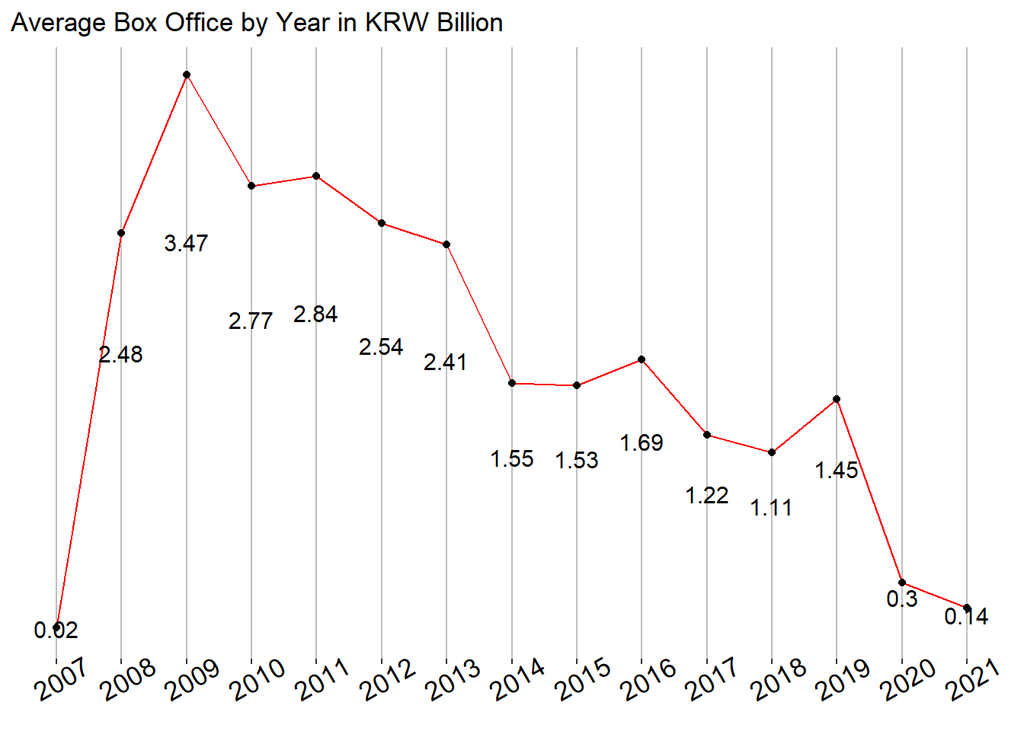

```r
ggplot(data = df_byYear,
       aes(x=Year, y=Mean_Box_Office, label = round(Mean_Box_Office/1000000000,2))) +
  geom_line(color = 'red') +
  geom_point()+
  labs(title="Average Box Office by Year in KRW Billion") +
  geom_text(size = 4, position = position_stack(vjust = 0.7))+
  theme(axis.text.x = element_text(size=13, angle=30, colour="black"),
        panel.background = element_rect(fill='white'),
  panel.grid.major = element_line(size = 0.5, linetype = 'solid',
                                colour = "gray"))+
  scale_x_continuous(name=NULL, breaks=seq(2007,2021)) +
  scale_y_continuous(name=NULL, breaks=NULL)
```

## Linear Regression

For this part, we are going to identify relationship among Box Office and other factors.

Before using linear regression, we are going to anticipate what factors are significant for successful Box Office.

### Genre

In genre, we anticipate that Action and SF is significant for creating better Box Office result. Action and Sf has characteristic of low burden on watching them. Usually, People are not required to concentrate on a movie when they are watching Action or SF genres.

```r
df_byGenre <- df_skip_na_0s;
table(df_byGenre$Genre)
```

```
##
##           0      Action   Adventure   Animation      Comedy       Crime
##          73        1647         130         964         836         413
## Documentary       Drama      Erotic      Family     Fantasy    Historic
##         651        3416        1723         106         172          61
##      Horror     Musical     Mystery      Others        Play      Romans
##         757          47         262         109         292        3820
##          SF    Thriller         War     Western
##         309         610          99           9
```

looking at table(), we identified 0 values in genre. We ignore them.

```r
df_byGenre <- df_byGenre %>% filter(Genre != 0)

#table(df_byGenre$Genre)
df_byGenre <- df_byGenre %>%
  group_by(Genre) %>%
  summarise(Count = n(), Mean = mean(Box_office), Sum = sum(Box_office))
```

The result is quite different from our expectation. Historic has highest Average Box Office among genres. Action and SF are ranked at 4th and 6th position.

The reason why Historic genre is powerful may that Historic genre has wider range of audience than other genres. Not only 20-30s but also 50-60s are willing to watch this genre. ‘Roaring Currents’ has 17 million audiences, which is highest record in Korea. It is not possible to attracting only 20-30s.

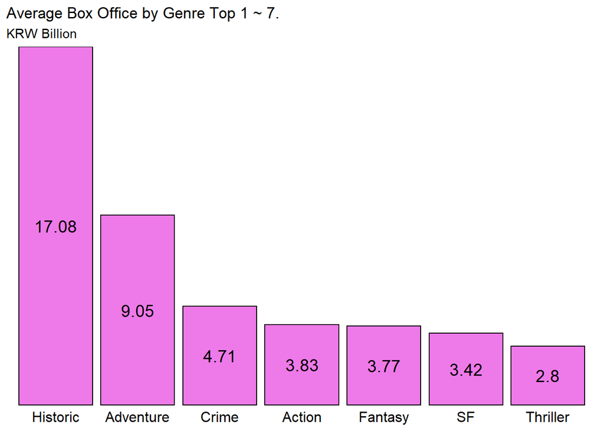

```r
ggplot(data= df_byGenre, aes(x=Genre, y=Mean,
      label = round(Mean/1000000000,2)))+
  geom_bar(stat='identity', fill="orchid2", colour='black') +
  scale_x_discrete(name = NULL,
                   limits = c("Historic", "Adventure", "Crime", "Action", "Fantasy", "SF", "Thriller"))+
  geom_text(size = 5, position = position_stack(vjust = 0.5))+
  scale_y_discrete(name = NULL) +
  theme(axis.ticks = element_blank()) +
  labs(title = "Average Box Office by Genre Top 1 ~ 7.",
       subtitle="KRW Billion")+
  theme(axis.text.x = element_text(size = 12, colour='black'),
        panel.background = element_rect(fill='white'))
```

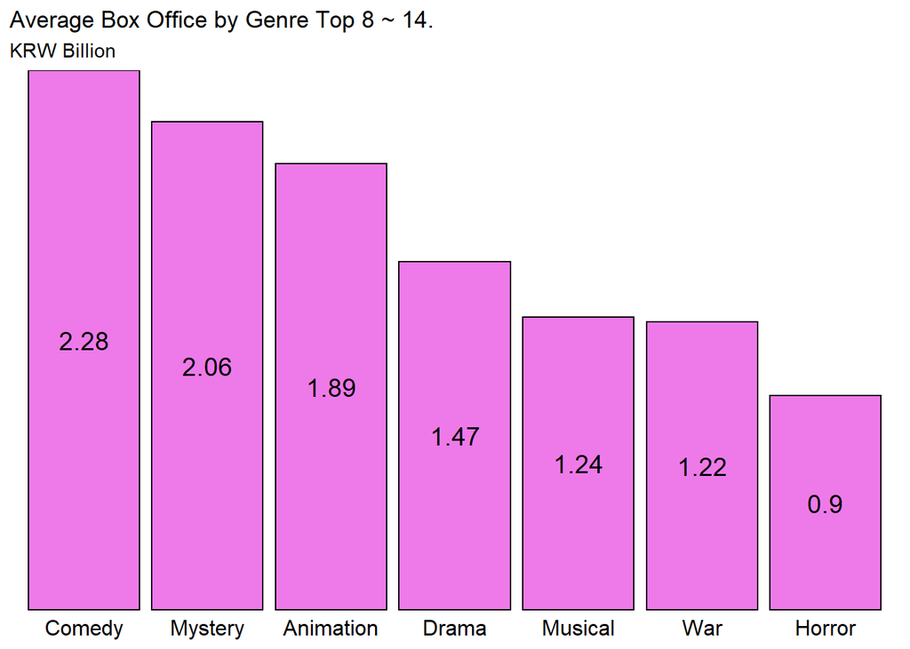

```r
ggplot(data= df_byGenre, aes(x=Genre, y=Mean,
      label = round(Mean/1000000000,2)))+
  geom_bar(stat='identity', fill="orchid2", colour='black') +
  scale_x_discrete(name = NULL,
                   limits = c("Comedy", "Mystery","Animation", "Drama", "Musical", "War", "Horror"))+
  geom_text(size = 5, position = position_stack(vjust = 0.5))+
  scale_y_discrete(name = NULL) +
  theme(axis.ticks = element_blank()) +
  labs(title = "Average Box Office by Genre Top 8 ~ 14.",
       subtitle = "KRW Billion")+
  theme(axis.text.x = element_text(size = 12, colour='black'),
        panel.background = element_rect(fill='white'))
```

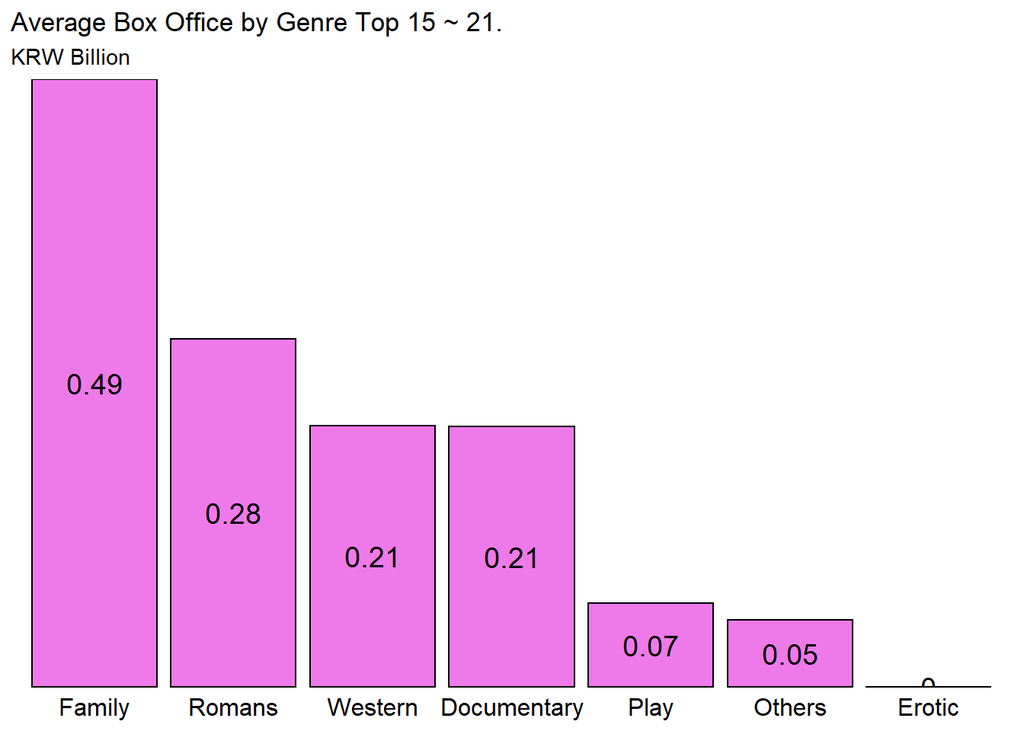

```r
ggplot(data= df_byGenre, aes(x=Genre, y=Mean,
      label = round(Mean/1000000000,2)))+
  geom_bar(stat='identity', fill="orchid2", colour='black') +
  scale_x_discrete(name = NULL,
                   limits = c("Family", "Romans", "Western","Documentary", "Play", "Others", "Erotic"))+
  geom_text(size = 5, position = position_stack(vjust = 0.5))+
  scale_y_discrete(name = NULL) +
  theme(axis.ticks = element_blank()) +
  labs(title = "Average Box Office by Genre Top 15 ~ 21.",
       subtitle = "KRW Billion")+
  theme(axis.text.x = element_text(size = 12, colour="black"),
        panel.background = element_rect(fill='white'))
```

### Nationality

```r
df_byNation <- df_skip_na_0s
df_byNation <- df_byNation %>%
  group_by(Nationality) %>%
  summarise(Count = n(), Proportion = n()/nrow(df_byNation)*100,Mean_Box_Office = mean(Box_office), Sum = sum(Box_office))
```

Looking at the data ordered by count, Korea, Japan and USA occupies almost 80%. Therefore, we only focus on those three countries.

```r
df_byNation[order(df_byNation$Count, decreasing = T),]
```

```
## # A tibble: 69 x 5
##    Nationality Count Proportion Mean_Box_Office     Sum
##    <chr>       <int>      <dbl>           <dbl>   <dbl>
##  1 한국         5333      32.3      2694991273. 1.44e13
##  2 일본         4211      25.5        73683807. 3.10e11
##  3 미국         3482      21.1      2848087297. 9.92e12
##  4 프랑스        588       3.56      255327375. 1.50e11
##  5 영국          538       3.26      373069192. 2.01e11
##  6 중국          369       2.24      195290491. 7.21e10
##  7 독일          302       1.83      202886920. 6.13e10
##  8 캐나다        204       1.24       80063474. 1.63e10
##  9 스페인        187       1.13      179603719. 3.36e10
## 10 홍콩          166       1.01      131487711. 2.18e10
## # ... with 59 more rows
```

As Korea and USA occupies significant percentage of all movies, they have about Box office of KRW 2.7 Billion per movie. However, movies from Japan only record KRW 0.07 Billion per movie. It can be a reason that movies from Japan are mostly made for sexual arousal. They are not made for attracting lots of people. On other hands, movies from USA recorded higher average Box Office than from Korea. It can be a reason that most of movies from USA are movies that recorded great success in the world so distributors import them. In contrast, movies made in Korea are shown themselves in Korea first. Some of them may not be successful.

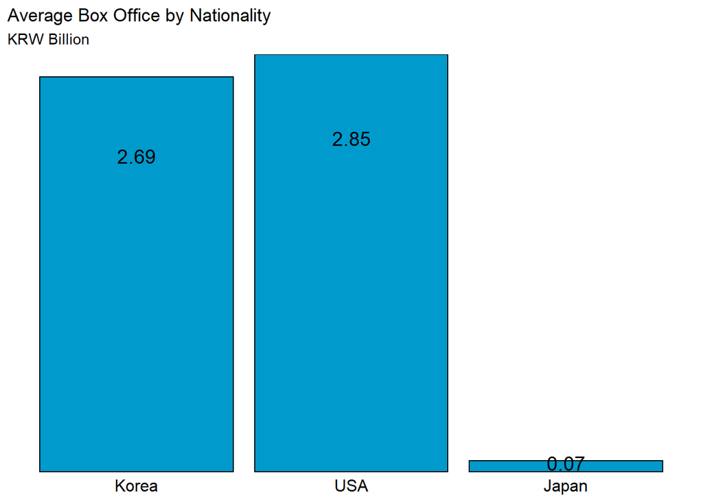

```r
ggplot(data= df_byNation, aes(x=Nationality, y=Mean_Box_Office,
      label = round(Mean_Box_Office/1000000000,2)))+
  geom_bar(stat='identity', fill="deepskyblue3", colour='black') +
  scale_x_discrete(name = NULL, breaks = c("한국","미국","일본"), labels = c("Korea","USA","Japan"),limits=c("한국","미국","일본"))+
  geom_text(size = 5, position = position_stack(vjust = 0.8))+
  scale_y_discrete(name = NULL) +
  theme(axis.ticks = element_blank()) +
  labs(title = "Average Box Office by Nationality",
       subtitle = "KRW Billion")+
  theme(axis.text.x = element_text(size = 12, colour="black"),
        panel.background = element_rect(fill='white'))
```

### Rate

```r
df_byRate <- df_skip_na_0s
```

```r
table(df_byRate$Rate)
```

```
##
##     All Over_12 Over_15 Over_18
##    1832    2186    4085    8403
```

Movies rated as over 18 occupies half of the data but recorded lowest average Box Office. It can be a reason that most of Japan movies are made for sexual arousal so it occupies lots of proportion but record low average Box Office. The highest average Box office is on Over 12 group. It may be because Over 12 can attract elementary school students and their parents than Over 15 cannot do.

```r
df_byRate <- df_byRate %>%
  group_by(Rate) %>%
  summarise(Count = n(), Proportion = n()/nrow(df_byRate)*100,
            Mean_Box_Office = mean(Box_office),
            Sum_Box_Office = sum(Box_office))
```

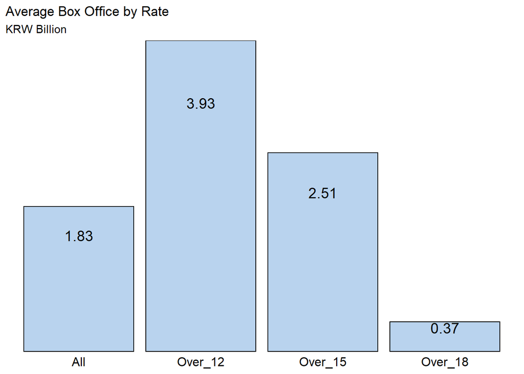

```r
ggplot(data= df_byRate, aes(x=Rate, y=Mean_Box_Office,
      label = round(Mean_Box_Office/1000000000,2)))+
  geom_bar(stat='identity', fill="slategray2", colour='black') +
  scale_x_discrete(name = NULL)+
  geom_text(size = 5, position = position_stack(vjust = 0.8))+
  scale_y_discrete(name = NULL) +
  theme(axis.ticks = element_blank()) +
  labs(title = "Average Box Office by Rate",
       subtitle = "KRW Billion")+
  theme(axis.text.x = element_text(size = 12, colour="black"),
        panel.background = element_rect(fill='white'))
```

### Artistic

```r
df_byArtistic <- df_skip_na_0s
```

```r
df_byArtistic <- df_byArtistic %>%
  group_by(Artistic) %>%
  summarise(Count = n(), Proportion = n()/nrow(df_byArtistic)*100,
            Mean_Box_Office = mean(Box_office), Total_Box_Office = sum(Box_office))
```

As we can guess from their name, Artistic movies don’t seem to generate great success.

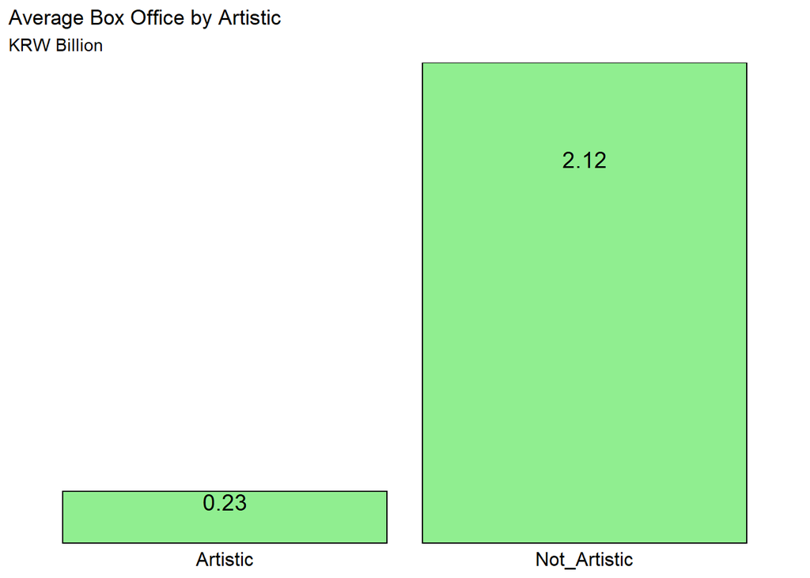

```r
ggplot(data= df_byArtistic, aes(x=Artistic, y=Mean_Box_Office,
      label = round(Mean_Box_Office/1000000000,2)))+
  geom_bar(stat='identity', fill="palegreen2", colour='black') +
  scale_x_discrete(name = NULL)+
  geom_text(size = 5, position = position_stack(vjust = 0.8))+
  scale_y_discrete(name = NULL) +
  theme(axis.ticks = element_blank()) +
  labs(title = "Average Box Office by Artistic",
       subtitle = "KRW Billion")+
  theme(axis.text.x = element_text(size = 12, colour="black"),
        panel.background = element_rect(fill='white'))
```

Based on analysis so far, we are going to check whether the result is statistically significant through linear regression.

To prevent influencing raw data, we make a new data frame.

```r
df_regression <- df_skip_na_0s
```

For processing linear regression for categorical variable, it is needed convert their values into separate columns.

Categorical variables what we use for this linear regression are Rate, Genre, Nationality, Artistic. Make columns for each values in the columns.

If the column has value of 1, it means that this movie has element of the column and 0 not.

```r
df_regression$Over_12 = df_regression$Rate == 'Over_12'
df_regression$All = df_regression$Rate == 'All'
df_regression$Over_16 = df_regression$Rate == 'Over_16'
df_regression$Over_15 = df_regression$Rate == 'Over_15'
df_regression$Over_18 = df_regression$Rate == 'Over_18'
```

```r
unique(df_regression$Genre)
```

```
##  [1] "Comedy"      "Historic"    "SF"          "Action"      "Fantasy"
##  [6] "Animation"   "Drama"       "Adventure"   "Crime"       "Mystery"
## [11] "War"         "Romans"      "Thriller"    "Documentary" "Horror"
## [16] "Musical"     "Family"      "Play"        "Others"      "Western"
## [21] "Erotic"      "0"
```

```r
df_regression$SF = df_regression$Genre == 'SF'
df_regression$Family = df_regression$Genre == 'Family'
df_regression$Play = df_regression$Genre == 'Play'
df_regression$Horror = df_regression$Genre == 'Horror'
df_regression$Others = df_regression$Genre == 'Others'
df_regression$Documentary = df_regression$Genre == 'Documentary'
df_regression$Drama = df_regression$Genre == 'Drama'
df_regression$Romans = df_regression$Genre == 'Romans'
df_regression$Musical = df_regression$Genre == 'Musical'
df_regression$Mystery = df_regression$Genre == 'Mystery'
df_regression$Crime = df_regression$Genre == 'Crime'
df_regression$Historic = df_regression$Genre == 'Historic'
df_regression$Western = df_regression$Genre == 'Western'
df_regression$Erotic = df_regression$Genre == 'Erotic'
df_regression$Thriller = df_regression$Genre == 'Thriller'
df_regression$Animation = df_regression$Genre == 'Animation'
df_regression$Action = df_regression$Genre == 'Action'
df_regression$Adventure = df_regression$Genre == 'Adventure'
df_regression$War = df_regression$Genre == 'War'
df_regression$Comedy = df_regression$Genre == 'Comedy'
df_regression$Fantasy = df_regression$Genre == 'Fantasy'
```

```r
table(df_regression$Nationality)
```

```
##
##                 그리스                   기타       남아프리카공화국
##                      5                     44                      2
##               네덜란드               노르웨이               뉴질랜드
##                     31                     34                     12
##                   대만                 덴마크                   독일
##                     39                     52                    302
##                 러시아               루마니아             마케도니아
##                    148                      6                      4
##             말레이시아                 멕시코                 모로코
##                     12                     34                      1
##                   몰타                   몽고                   미국
##                      1                      1                   3482
##             베네수엘라                 베트남                 벨기에
##                      4                      5                     27
##               보스니아                   부탄               불가리아
##                      1                      1                      3
##                 브라질               세르비아                 스웨덴
##                     18                      2                     43
##                 스위스                 스페인             슬로바키아
##                      5                    187                      2
##               싱가포르 아랍에미리트연합국정부             아르헨티나
##                      7                      3                     14
##             아이슬란드               아일랜드             에스토니아
##                     13                     36                      1
##                   영국             오스트리아               우루과이
##                    538                     13                      2
##           우즈베키스탄             우크라이나                 이라크
##                      1                      8                      2
##                   이란               이스라엘               이탈리아
##                     20                     19                    123
##                   인도             인도네시아                   일본
##                     43                      7                   4211
##                   중국                   체코                   칠레
##                    369                     13                     14
##             카자흐스탄                 캐나다               콜롬비아
##                      5                    204                      2
##                   쿠바             크로아티아                   태국
##                      1                      6                     45
##                   터키             팔레스타인                   페루
##                     17                      2                      5
##               포르투갈                 폴란드                 프랑스
##                      2                     21                    588
##                 핀란드                 필리핀                   한국
##                     22                      3                   5333
##                 헝가리                   호주                   홍콩
##                     26                     93                    166
```

Nationalities of USA, Japan, and Korea occupy most of the movies (about 80%) listed in Korea.

So, in this linear regression, we just focus on whether this movie is made in USA, Japan, or Korea.

```r
df_regression[df_regression["Nationality"] == '미국',"Nationality"] = "USA"
df_regression[df_regression["Nationality"] == '한국',"Nationality"] = "Korea"
df_regression[df_regression["Nationality"] == '일본',"Nationality"] = "Japan"
```

```r
df_regression$USA = df_regression$Nationality == 'USA'
df_regression$Japan = df_regression$Nationality == 'Japan'
df_regression$Korea = df_regression$Nationality == 'Korea'
```

```r
unique(df_regression$Artistic)
```

```
## [1] "Not_Artistic" "Artistic"
```

We make new column for Artistic.

```r
df_regression$Artistic = df_regression$Artistic == 'Artistic'
df_regression$Not_artistic = df_regression$Artistic == 'Not_Artistic'
```

Next, we are going to identify outliers for numerical variables.

```r
library(ggplot2)
```

1. Audience

   It seems that we don’t have outstanding values.

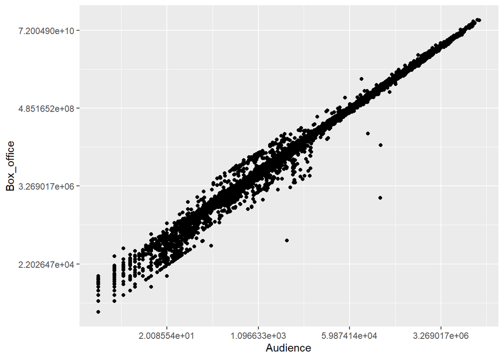

```r
ggplot(data=df_regression,aes(x=Audience, y=Box_office)) +
  geom_point()+
  scale_x_continuous(trans='log')+
  scale_y_continuous(trans='log')
```

2. Number of Screens

   values lower than 10 screens looks bizarre.

   we are going to drop those values for regression.

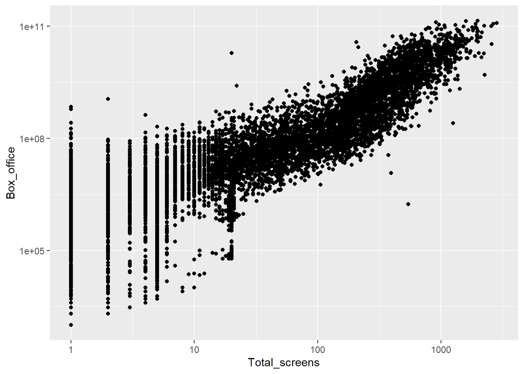

```r
ggplot(data=df_regression,aes(x=Total_screens, y=Box_office)) +
  geom_point()+
  scale_y_continuous(trans='log10')+
  scale_x_continuous(trans='log10')
```

```r
df_regression <- df_regression %>%
  filter(Total_screens > 10)
```

Box_office, Audience, Total_screens are too large than other variables so that they can dominate the result.

so, we scale them using log base 10.

```r
df_regression$Box_log10 <- log(df_regression$Box_office, 10)
df_regression$Aud_log10 <- log(df_regression$Audience, 10)
df_regression$screen_log10 <- log(df_regression$Total_screens, 10)
```

Now, it’s time to build regression model.

```r
Movie_reg <- lm(Box_log10 ~ Aud_log10 + screen_log10 +All + Over_12 + Over_15 + Over_16+ Over_18 + SF + Family + Play + Horror + Documentary + Drama + Romans + Musical + Mystery + Crime + Historic + Western + Erotic + Thriller + Animation + Action + Adventure + War + Comedy + Fantasy + USA + Japan + Korea + Artistic + Not_artistic, data=df_regression)

summary(Movie_reg)
```

```
##
## Call:
## lm(formula = Box_log10 ~ Aud_log10 + screen_log10 + All + Over_12 +
##     Over_15 + Over_16 + Over_18 + SF + Family + Play + Horror +
##     Documentary + Drama + Romans + Musical + Mystery + Crime +
##     Historic + Western + Erotic + Thriller + Animation + Action +
##     Adventure + War + Comedy + Fantasy + USA + Japan + Korea +
##     Artistic + Not_artistic, data = df_regression)
##
## Residuals:
##      Min       1Q   Median       3Q      Max
## -0.98279 -0.02658  0.00339  0.03135  0.32232
##
## Coefficients: (3 not defined because of singularities)
##                    Estimate Std. Error t value Pr(>|t|)
## (Intercept)       3.7046750  0.0112772 328.510  < 2e-16 ***
## Aud_log10         1.0046046  0.0013308 754.900  < 2e-16 ***
## screen_log10      0.0552340  0.0028879  19.126  < 2e-16 ***
## AllTRUE          -0.0010623  0.0033907  -0.313   0.7541
## Over_12TRUE       0.0113397  0.0026215   4.326 1.54e-05 ***
## Over_15TRUE       0.0131062  0.0022616   5.795 7.12e-09 ***
## Over_16TRUE              NA         NA      NA       NA
## Over_18TRUE              NA         NA      NA       NA
## SFTRUE           -0.0117580  0.0122587  -0.959   0.3375
## FamilyTRUE        0.0049498  0.0135048   0.367   0.7140
## PlayTRUE          0.4657530  0.0127566  36.511  < 2e-16 ***
## HorrorTRUE        0.0125863  0.0117641   1.070   0.2847
## DocumentaryTRUE   0.0338244  0.0115807   2.921   0.0035 **
## DramaTRUE         0.0070144  0.0110962   0.632   0.5273
## RomansTRUE       -0.0211353  0.0109970  -1.922   0.0547 .
## MusicalTRUE       0.1606214  0.0152295  10.547  < 2e-16 ***
## MysteryTRUE       0.0223563  0.0120924   1.849   0.0645 .
## CrimeTRUE         0.0075114  0.0117486   0.639   0.5226
## HistoricTRUE     -0.0009518  0.0141275  -0.067   0.9463
## WesternTRUE      -0.0144215  0.0658267  -0.219   0.8266
## EroticTRUE       -0.1370592  0.0181199  -7.564 4.39e-14 ***
## ThrillerTRUE     -0.0038779  0.0115651  -0.335   0.7374
## AnimationTRUE    -0.0113454  0.0114956  -0.987   0.3237
## ActionTRUE       -0.0053806  0.0113425  -0.474   0.6352
## AdventureTRUE     0.0005361  0.0132383   0.040   0.9677
## WarTRUE          -0.0145132  0.0159108  -0.912   0.3617
## ComedyTRUE        0.0030764  0.0113599   0.271   0.7865
## FantasyTRUE       0.0126364  0.0127912   0.988   0.3232
## USATRUE           0.0046302  0.0023523   1.968   0.0491 *
## JapanTRUE         0.0171462  0.0032913   5.210 1.95e-07 ***
## KoreaTRUE        -0.0233825  0.0023181 -10.087  < 2e-16 ***
## ArtisticTRUE      0.0458818  0.0020051  22.882  < 2e-16 ***
## Not_artisticTRUE         NA         NA      NA       NA
## ---
## Signif. codes:  0 '***' 0.001 '**' 0.01 '*' 0.05 '.' 0.1 ' ' 1
##
## Residual standard error: 0.06486 on 7233 degrees of freedom
## Multiple R-squared:  0.9976, Adjusted R-squared:  0.9976
## F-statistic: 1.021e+05 on 29 and 7233 DF,  p-value: < 2.2e-16
```

The regression has really small p-value so we can say that this result is statistically significant.

#### Significant independent variable

<0.1% level>

- Audience_log10
- Screen_log10
- Over_12TRUE
- Over_15TRUE
- PlayTRUE
- MusicalTRUE
- EroticTRUE
- JapanTRUE
- KoreaTRUE
- ArtisticTRUE

<1% level>

- DocumentaryTRUE

<5% level>

- USATRUE

#### Interpretation

The result from the regression is quite different from our expectation.

(it is obvious that audience and number of screen has positive effect on box office)

The table below describes factors for successful movie based on expectation and result of the regression.

[output not shown]

## Conclusion

Movie industry was already in danger from the introduction of smartphone. Covid 19 made the situation much serious.

When you are wondering what movies to distribute in Korea, consider these:

1. Movies that can be distributed not only to theater but also OTT services
2. check descriptions of movies
   1. is the movie rated as over 12 or over 15?
   2. is the movie has genre of musical or play or documentary?
   3. is the movie made in USA or Japan?
   4. is the movie artistic?